# Имитационное моделирование

Лабораторная работа №8. Реализация модели SIR в дискретно-событийном подходе

Глущенко Евгений Игоревич

Российский университет дружбы народов имени Патриса Лумумбы

2026-05-29

# Информация

## Докладчик и работа

- Глущенко Евгений Игоревич
- студент группы НФИбд-01-23
- студенческий билет: 1132239110
- РУДН имени Патриса Лумумбы
- тема: дискретно-событийная модель SIR
- средства: Julia, DrWatson, ConcurrentSim, ResumableFunctions, CairoMakie, Literate.jl

# Цель и задачи

## Цель и постановка

- Изучить дискретно-событийный подход к имитационному моделированию
- Реализовать стохастическую модель SIR на `ConcurrentSim`
- Сравнить имитацию со стохастическим ансамблем и детерминированной ОДУ
- Провести анализ чувствительности к параметрам `β`, `c`, `γ`
- Оценить производительность и подготовить воспроизводимые материалы

## Что требовалось сделать

1. Создать Julia-проект в структуре `DrWatson`
2. Реализовать модуль `src/SIRModels.jl`
3. Преобразовать код в литературный стиль
4. Сгенерировать `clean`, `markdown` и `ipynb`-материалы
5. Добавить вычисление для набора параметров и интегрировать в отчёт

# Теоретическая часть

## Модель SIR

Классы популяции размера `N`:

- `S` — восприимчивые
- `I` — инфицированные
- `R` — переболевшие

$$\frac{dS}{dt} = -\beta c \frac{SI}{N}$$
$$\frac{dI}{dt} = \beta c \frac{SI}{N} - \gamma I$$

Параметры:

- `β` — вероятность передачи
- `c` — частота контактов
- `γ` — интенсивность выздоровления

$$R_0 = \frac{\beta c}{\gamma}$$

При `R_0 > 1` — вспышка, при `R_0 \le 1` — затухание.

## Дискретно-событийный подход

- Состояние меняется только в моменты событий
- Каждый индивид — отдельный процесс
- `ResumableFunctions`: `@resumable` и `@yield`
- `ConcurrentSim`: виртуальное время, `timeout`, `run`

Логика индивида:

- пока `:S` — ждёт контакт через `Exp(1/c)`
- выбирает случайного собеседника
- если тот `:I`, заражается с вероятностью `β`
- став `:I`, выздоравливает через `Exp(1/γ)`

## Конечный размер эпидемии

- Итоговая доля переболевших `z = R(\infty)/N`
- Удовлетворяет уравнению конечного размера:

$$z = 1 - e^{-R_0 z}$$

- При `R_0 \le 1` корень `z = 0` (эпидемии нет)
- При `R_0 > 1` положительный корень определяет масштаб эпидемии
- Решается методом простых итераций, служит аналитической базой для сравнения

# Реализация

## Структура проекта и запуск

- `src/SIRModels.jl` — модель, ОДУ, скан, графики
- `scripts/sir.jl` — базовый эксперимент
- `scripts/sir_parameters.jl` — анализ чувствительности
- `scripts/tangle.jl` — генерация literate-артефактов

```bash
cd ~/labs/lab08/project
julia --project=. -e \
  'include("scripts/sir.jl")'
julia --project=. -e \
  'include("scripts/sir_parameters.jl")'
julia --project=. scripts/tangle.jl
```

## Инициализация и базовый запуск

Активация окружения `Pkg.instantiate()`

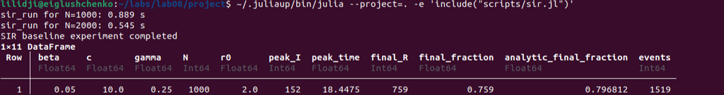

Базовый запуск `scripts/sir.jl`

## Процесс агента `live`

```julia
@resumable function live(env, individual, m)
    while individual.status == :S
        @yield timeout(env, rand(m.rng, Exponential(1 / m.c)))
        alter = individual
        while alter === individual
            alter = m.individuals[rand(m.rng, 1:length(m.individuals))]
        end
        if alter.status == :I && rand(m.rng) < m.β
            individual.status = :I
            infection_update!(env, m)
        end
    end
    if individual.status == :I
        @yield timeout(env, rand(m.rng, Exponential(1 / m.γ)))
        individual.status = :R
        recovery_update!(env, m)
    end
end
```

## Создание и запуск модели

- `make_sir_model(u0, p)` — создаёт популяцию индивидов и временные ряды
- `activate_sir!(m)` — регистрирует процессы агентов
- `run_sir!(m, tf)` — продвигает виртуальное время до `tf`
- `out(m)` — собирает результат в `DataFrame` с колонками `t`, `S`, `I`, `R`
- `StableRNG` обеспечивает полную воспроизводимость прогонов

# Результаты базового эксперимента

## Базовый сценарий

Параметры:

- `u0 = [990, 10, 0]`
- `p = [0.05, 10.0, 0.25]`
- `tmax = 40`, `seed = 1234`
- `R_0 = 2.0`

Результаты:

- пик инфицированных: `152`
- время пика: `t ≈ 18.4`
- переболело: `759` (`0.759`)
- аналитика: `0.797`
- событий: `1519`

## Динамика численности `S`, `I`, `R`

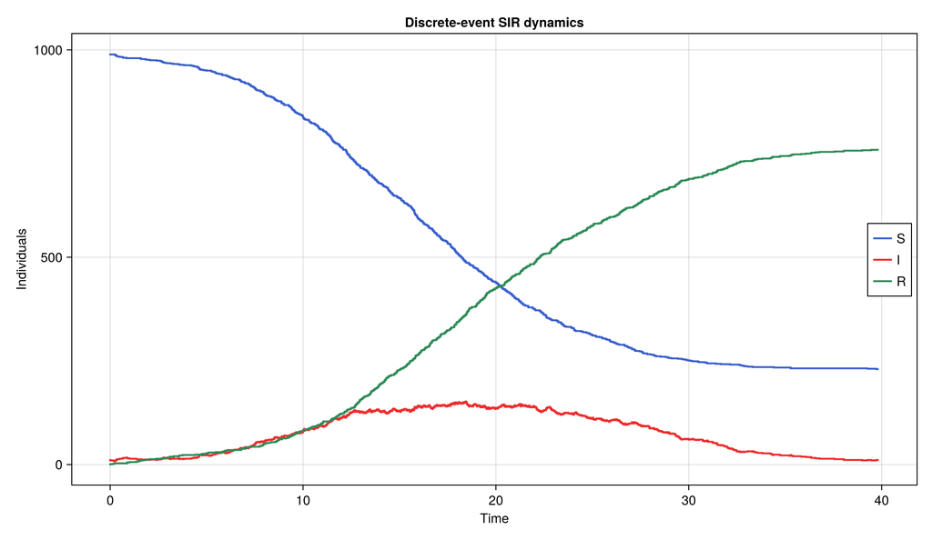

Дискретно-событийная динамика SIR

## Сравнение с детерминированной моделью

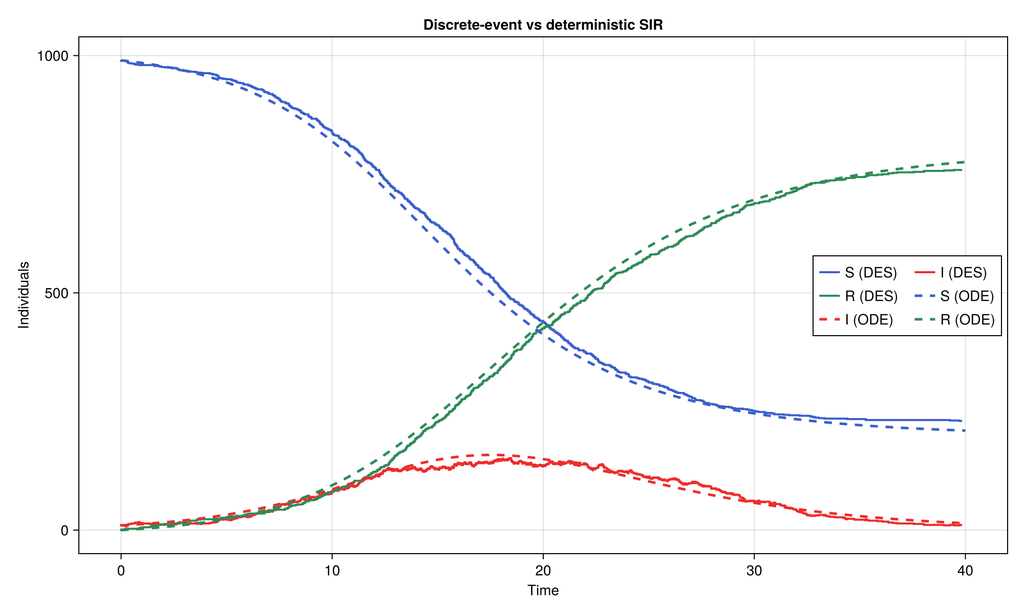

Дискретно-событийная (сплошные) и детерминированная (штриховые)

Детерминированная ОДУ: пик `158` в `t = 17.5`, доля `0.776` — имитация согласуется в пределах стохастического разброса.

## Ансамбль стохастических реализаций

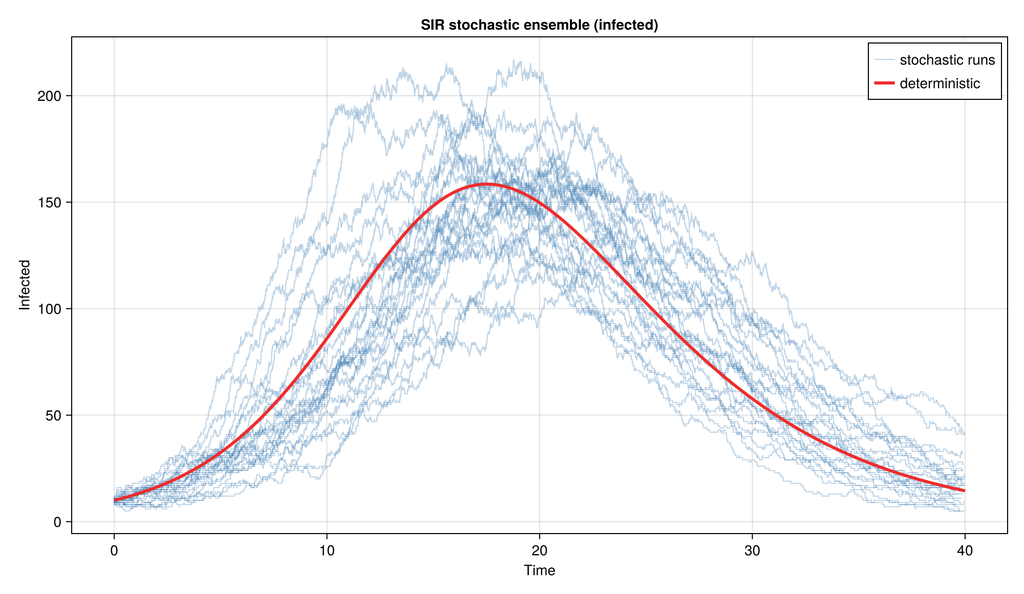

Ансамбль из 24 прогонов

- средний пик: `172.0`
- разброс пика: `133…217`
- средняя доля: `0.771`
- ранних затуханий нет: при `R_0 = 2` и `I_0 = 10` эпидемия разгорается почти всегда

## Фазовый портрет

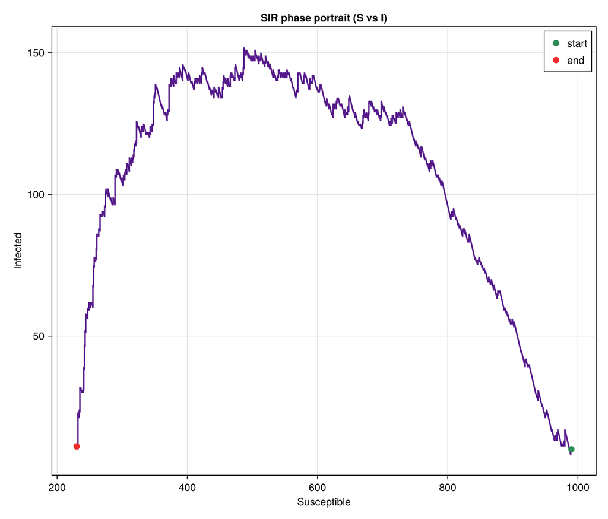

Фазовый портрет `S`–`I`

Пик достигается вблизи `S = N/R_0 = 500` — порога устойчивости.

# Анализ чувствительности

## Сетка параметров и результаты

Сетка `β × c × γ` (`3×3×3 = 27` сценариев) при `c = 10`:

| `β` | `γ` | `R0` | `mean_peak_I` | `final` | `analytic` |
| --- | --- | --- | --- | --- | --- |
| 0.03 | 0.33 | 0.91 | 14.0 | 0.052 | 0.000 |
| 0.03 | 0.25 | 1.20 | 37.3 | 0.199 | 0.314 |
| 0.05 | 0.25 | 2.00 | 192.3 | 0.793 | 0.797 |
| 0.07 | 0.25 | 2.80 | 292.5 | 0.929 | 0.925 |
| 0.07 | 0.20 | 3.50 | 373.8 | 0.967 | 0.966 |

При `R_0 \le 1` эпидемии нет; при `R_0 > 1` масштаб растёт.

## Запуск анализа чувствительности

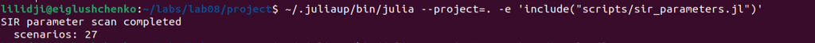

Запуск `scripts/sir_parameters.jl` — 27 сценариев

## Высота пика по `β` и `c`

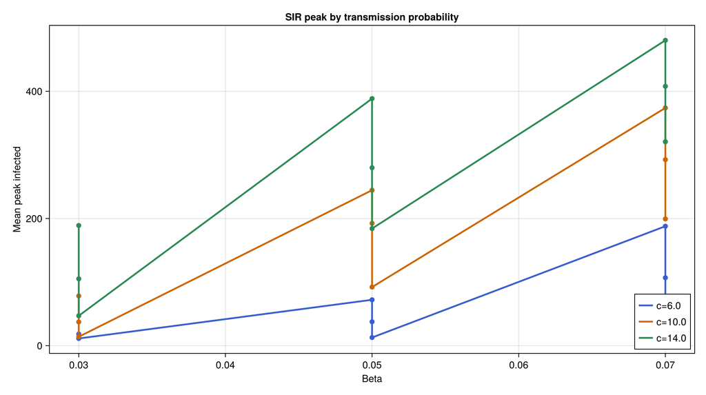

Пик по `β`

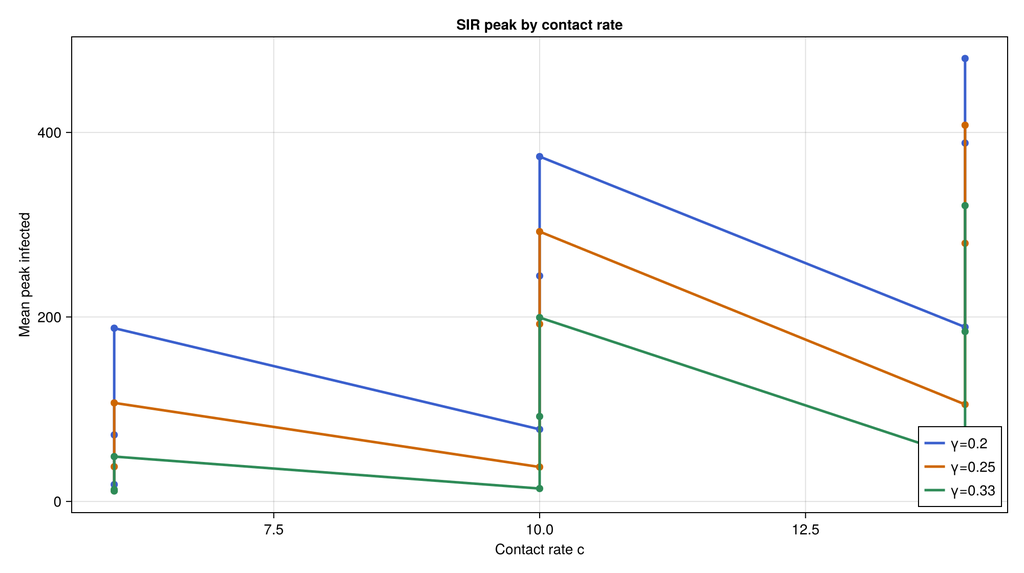

Пик по `c`

`β` и `c` входят в `R_0` через произведение `βc` и действуют симметрично.

## Конечный размер и тепловая карта

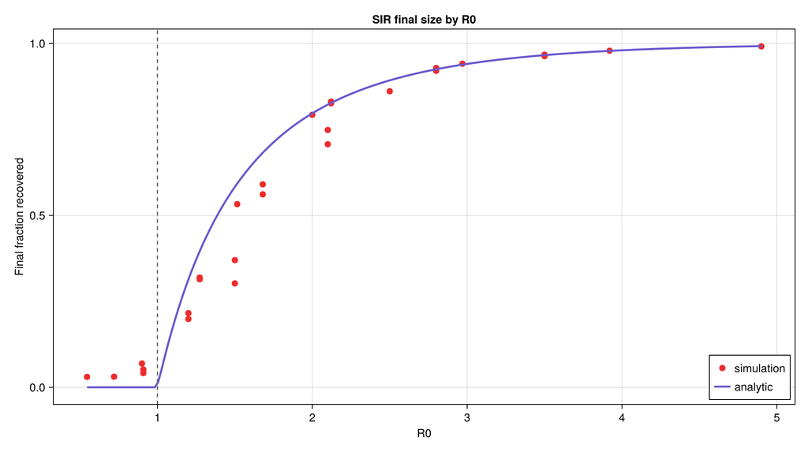

Доля переболевших по `R0`

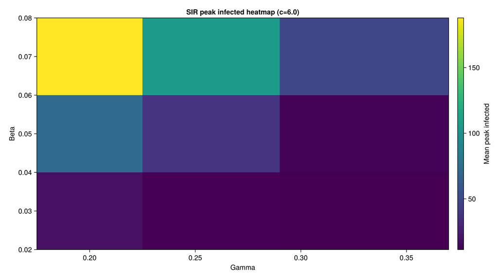

Пик по `(β, γ)`

Имитация близка к кривой `z = 1 - e^{-R_0 z}`; вблизи `R_0 = 1` лежит ниже из-за стохастического затухания.

# Модификации и производительность

## Дополнительные модификации

Детерминированная длительность болезни:

- флаг `det_recovery`
- `Exp(1/γ)` заменяется на `1/γ`
- выздоровления синхроннее, пик уже

Производительность `sir_run`:

[output not shown]

# Воспроизводимость

## Literate-артефакты

- Единый источник `*_literate.jl` через `Literate.jl` порождает:
  - `clean`-скрипт (чистый код)
  - `markdown`-документ
  - исполняемый `ipynb`-ноутбук
- Генерация выполняется одним сценарием `scripts/tangle.jl`
- Notebook-файлы выполняются при генерации (`execute = true`)

```
generated for sir
generated for sir_parameters
```

## Генерация и проверка артефактов

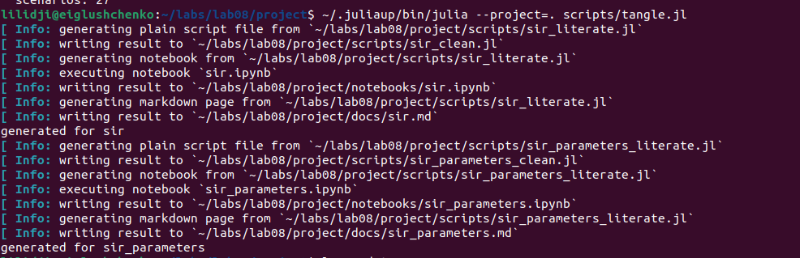

Запуск `scripts/tangle.jl`

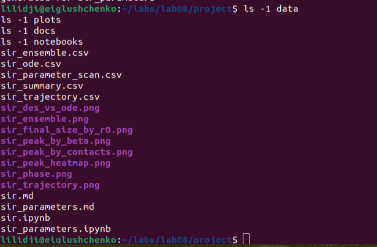

Проверка каталогов результатов

## Выводы

- Реализована стохастическая дискретно-событийная модель SIR на `ConcurrentSim`
- Базовый прогон (`R_0 = 2`): пик `152`, доля `0.759` — согласуется с ОДУ (`158`, `0.776`) и аналитикой (`0.797`)
- Ансамбль подтвердил стохастический разброс и низкую вероятность раннего вымирания
- Анализ чувствительности выявил пороговое поведение по `R_0`
- Реализованы детерминированная длительность болезни и оценка производительности
- Проект оформлен воспроизводимо с помощью `DrWatson` и `Literate`